# DV_FinalProject: **RELIGIONS, WAR & REFUGEES**

## 00. Create/Clone a github repository

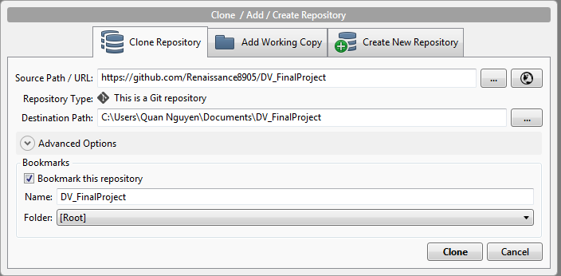

## 01. Create RStudio Project

[figure not shown]

## 02. Setup RStudio

- **00 Doc**: where .Rmd, html and graphics live
- **01 Data**: where data, csv’s will be stored
- **03 Tableau Workbooks**: Where visualizations are saved
- **04 Shiny**: ui.R and server.R

## 03. Download .CSV Files

The three datasets that will be used are:

- **Refugee Stats**: (http://popstats.unhcr.org/)

[figure not shown]

- **Militarized Disputes**: (http://www.correlatesofwar.org/news/mid-data-set-v4-01-available)

[figure not shown]

- **Religions by Nation**: (http://www.correlatesofwar.org/data-sets/world-religion-data)

[figure not shown]

The original and reformatted CSV’s can be found in **01 Data** folder.

## 04. ETL & Create Table on Database

- The ETL R scripts are **Refugees_Combined_ETL.r** and **Religion-WRP ETL.r**, both of which can be found in **01 Data** folder.
- Three tables are created in Oracle database:

CREATE TABLE Refugee_Stats ( Asylum_Country varchar2(4000), Origin_Country varchar2(4000), Record_Year number(38,4), Refugees number(38,4), Asylum_seekers number(38,4), Returned_Refugees number(38,4), IDPs number(38,4), Returned_IDPs number(38,4), Stateless_persons number(38,4), Others_of_concern number(38,4), Total_Population number(38,4) );

TABLE “MILITARIZED_DISPUTES”

STATE_ABBR VARCHAR2(4000 BYTE) Yes 1  
DISPNUM3 NUMBER(38,4) Yes 2  
DISPNUM4 NUMBER(38,4) Yes 3  
COUNTRY_CODE NUMBER(38,4) Yes 4  
START_DAY NUMBER(38,4) Yes 5  
START_MON NUMBER(38,4) Yes 6  
START_YEAR NUMBER(38,4) Yes 7  
END_DAY NUMBER(38,4) Yes 8  
END_MON NUMBER(38,4) Yes 9  
END_YEAR NUMBER(38,4) Yes 10  
SIDE_A_BOOL NUMBER(1,0) Yes 11  
REVISIONIST_STATE_BOOL NUMBER(1,0) Yes 12  
REVISION_TYPE2 NUMBER(38,4) Yes 13  
REVISION_TYPE1 NUMBER(38,4) Yes 14  
FATALITY_LEVEL NUMBER(38,4) Yes 15  
FATALITY_PRECISE NUMBER(38,4) Yes 16  
HIGHEST_ACTION NUMBER(38,4) Yes 17  
HOSTILITY_LEVEL NUMBER(38,4) Yes 18  
ORIGINATOR_BOOL NUMBER(1,0) Yes 19

TABLE “RELIGIONS_BY_NATION”

STATE VARCHAR2(4000 BYTE) Yes 1  
NAME VARCHAR2(4000 BYTE) Yes 2  
DATATYPE VARCHAR2(4000 BYTE) Yes 3  
SOURCERELIAB VARCHAR2(4000 BYTE) Yes 4  
RECRELIAB VARCHAR2(4000 BYTE) Yes 5  
RELIABILEVEL VARCHAR2(4000 BYTE) Yes 6  
VERSION VARCHAR2(4000 BYTE) Yes 7  
SOURCECODE VARCHAR2(4000 BYTE) Yes 8  
YEAR NUMBER(38,4) Yes 9  
CHRSTPROT NUMBER(38,4) Yes 10  
CHRSTCAT NUMBER(38,4) Yes 11  
CHRSTORTH NUMBER(38,4) Yes 12  
CHRSTANG NUMBER(38,4) Yes 13  
CHRSTOTHR NUMBER(38,4) Yes 14  
CHRSTGEN NUMBER(38,4) Yes 15  
JUDORTH NUMBER(38,4) Yes 16  
JDCONS NUMBER(38,4) Yes 17  
JUDREF NUMBER(38,4) Yes 18  
JUDOTHR NUMBER(38,4) Yes 19  
JUDGEN NUMBER(38,4) Yes 20  
ISLMSUN NUMBER(38,4) Yes 21  
ISLMSHI NUMBER(38,4) Yes 22  
ISLMIBD NUMBER(38,4) Yes 23  
ISLMNAT NUMBER(38,4) Yes 24  
ISLMALW NUMBER(38,4) Yes 25  
ISLMAHM NUMBER(38,4) Yes 26  
ISLMOTHR NUMBER(38,4) Yes 27  
ISLMGEN NUMBER(38,4) Yes 28  
BUDMAH NUMBER(38,4) Yes 29  
BUDTHR NUMBER(38,4) Yes 30  
BUDOTHR NUMBER(38,4) Yes 31  
BUDGEN NUMBER(38,4) Yes 32  
ZOROGEN NUMBER(38,4) Yes 33  
HINDGEN NUMBER(38,4) Yes 34  
SIKHGEN NUMBER(38,4) Yes 35  
SHNTGEN NUMBER(38,4) Yes 36  
BAHGEN NUMBER(38,4) Yes 37  
TAOGEN NUMBER(38,4) Yes 38  
JAINGEN NUMBER(38,4) Yes 39  
CONFGEN NUMBER(38,4) Yes 40  
SYNCGEN NUMBER(38,4) Yes 41  
ANMGEN NUMBER(38,4) Yes 42  
NONRELIG NUMBER(38,4) Yes 43  
OTHRGEN NUMBER(38,4) Yes 44  
SUMRELIG NUMBER(38,4) Yes 45  
POP NUMBER(38,4) Yes 46  
CHRSTPROTPCT NUMBER(38,4) Yes 47  
CHRSTCATPCT NUMBER(38,4) Yes 48  
CHRSTORTHPCT NUMBER(38,4) Yes 49  
CHRSTANGPCT NUMBER(38,4) Yes 50  
CHRSTOTHRPCT NUMBER(38,4) Yes 51  
CHRSTGENPCT NUMBER(38,4) Yes 52  
JUDORTHPCT NUMBER(38,4) Yes 53  
JUDCONSPCT NUMBER(38,4) Yes 54  
JUDREFPCT NUMBER(38,4) Yes 55  
JUDOTHRPCT NUMBER(38,4) Yes 56  
JUDGENPCT NUMBER(38,4) Yes 57  
ISLMSUNPCT NUMBER(38,4) Yes 58  
ISLMSHIPCT NUMBER(38,4) Yes 59  
ISLMIBDPCT NUMBER(38,4) Yes 60  
ISLMNATPCT NUMBER(38,4) Yes 61  
ISLMALWPCT NUMBER(38,4) Yes 62  
ISLMAHMPCT NUMBER(38,4) Yes 63  
ISLMOTHRPCT NUMBER(38,4) Yes 64  
ISLMGENPCT NUMBER(38,4) Yes 65  
BUDMAHPCT NUMBER(38,4) Yes 66  
BUDTHRPCT NUMBER(38,4) Yes 67  
BUDOTHRPCT NUMBER(38,4) Yes 68  
BUDGENPCT NUMBER(38,4) Yes 69  
ZOROGENPCT NUMBER(38,4) Yes 70  
HINDGENPCT NUMBER(38,4) Yes 71  
SIKHGENPCT NUMBER(38,4) Yes 72  
SHNTGENPCT NUMBER(38,4) Yes 73  
BAHGENPCT NUMBER(38,4) Yes 74  
TAOGENPCT NUMBER(38,4) Yes 75  
JAINGENPCT NUMBER(38,4) Yes 76  
CONFGENPCT NUMBER(38,4) Yes 77  
SYNCGENPCT NUMBER(38,4) Yes 78  
ANMGENPCT NUMBER(38,4) Yes 79  
NONRELIGPCT NUMBER(38,4) Yes 80  
OTHRGENPCT NUMBER(38,4) Yes 81  
SUMRELIGPCT NUMBER(38,4) Yes 82  
TOTAL NUMBER(38,4) Yes 83  
DUALRELIG NUMBER(38,4) Yes 84

## 05. Visualizations

### Quan’s Stories

#### A. Start with a green thing in non-aggregated mode and make a boxplot

For **Religions by Nation** dataset:

- Put Name into Columns
- Put Budgen into Rows
- Choose Boxplot in Show Me

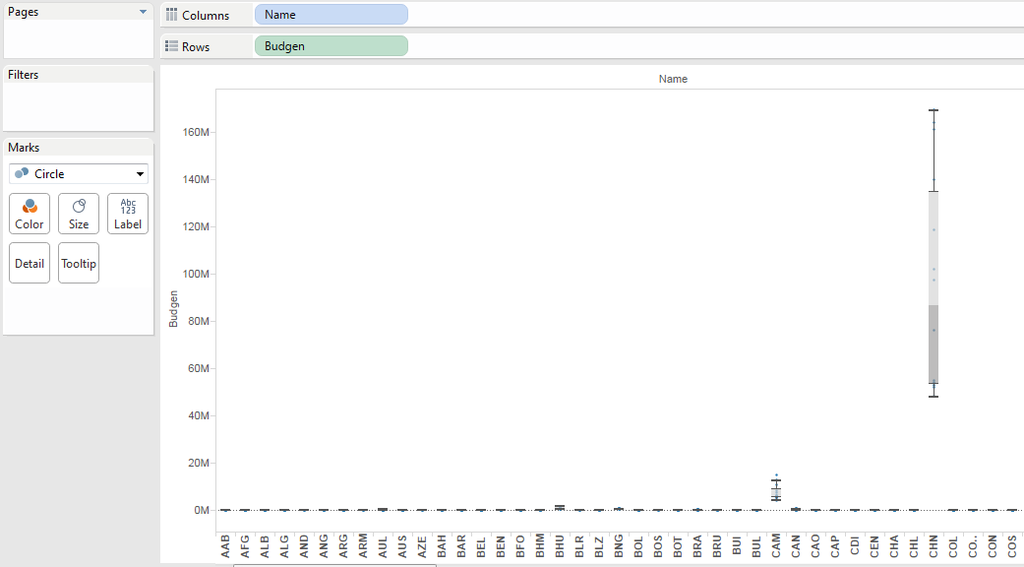

- Make a new barchart: put Name into Columns, Budgen into Rows
- Pick out interesting countries (filtering by Name as CHN, DRV, JPN, MYA, THI)
- Filter by Year greater than or equal to 1955 (to eliminate null values)
- Put Year in Pages to create a timeline slider
- Put Name in Marks as Color for labeling

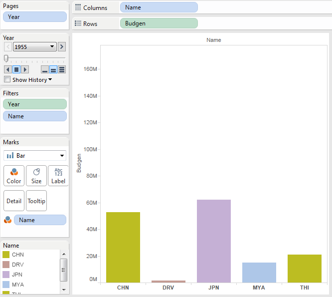

**Interesting Findings:**

- China vs Japan: Even though China and Japan has a striking difference in total population, for the early period (1945 – 1970), their Buddhist population was comparable (with Japan’s being little higher). However, from 1970 onwards, Buddhist population in China increased markedly and steadily, outstripping Japan completely.
- The interesting point about China’s increase is that even though it was rapid, there was a sudden drop (by no less than 50%) between 1995 and 2000, followed by a sudden comeback and plateau right in 2005.
- For Vietnam, after long period of slow but steady increase in Buddhist population between 1955-1995, there appears a sharp increase and plateau in 2000 (from 6.5M to 40M between 1995 and 2000).

#### B. Start with two green things and a map

For **Religions by Nation** dataset:

- Choose Name’s Geographic Role as Country/Region, then Add to Sheet
- Filter by Nonreligpct to be at least 15% (eliminating insignificant data)
- For Marks, put Name into Color as labeling, and Nonreligpct into Label for showing values

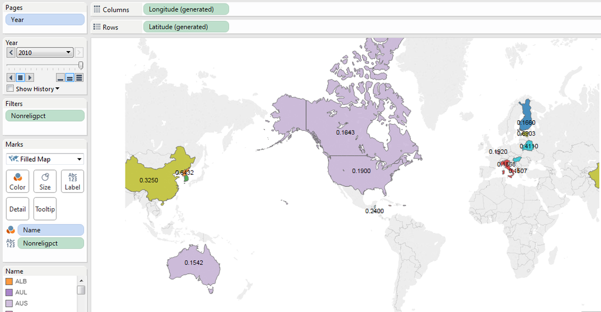

- Create a new scatterplot: put Year into Columns and Nonreligpct into Rows
- Put Name into Columns for different facets
- Pick out interesting countries (filtering by Name as CHN, CUB, CZE, FIN, JAM, PRK, RUS, USA)
- Put Name into Color in Marks for labeling

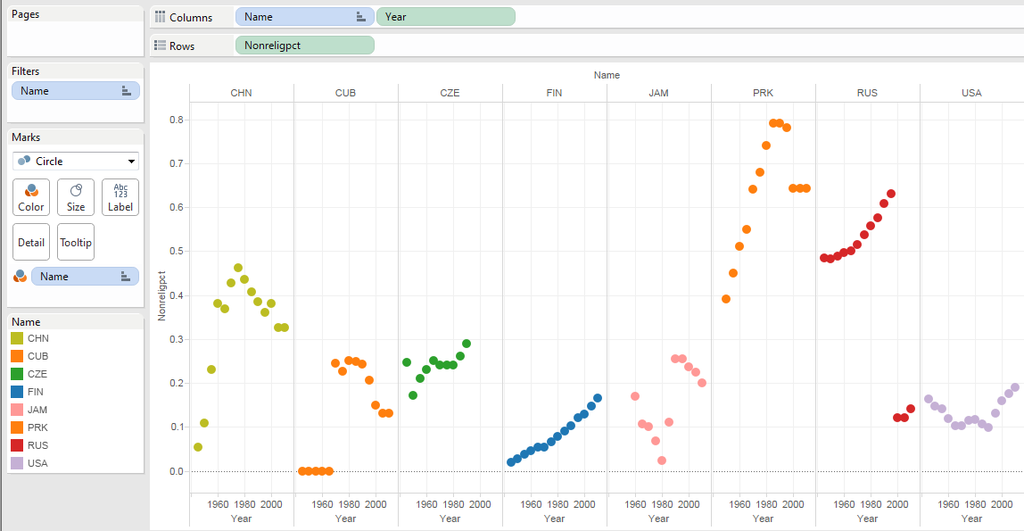

## 06. Shiny App for Interesting Visualizations